# R & Tidyverse Basics

2023-03-17

## *R*

- freie Softwareumgebung
- flexible Anwendungsmöglichkeiten, u.a. Statistik, Textverarbeitung, Visualisierung, Netzwerkanalyse, API-Zugriff, Webscraping, Interaktive Anwendungen….
- Zahlreiche Funktionen werden über sogenannte “Packages” bereitgestellt
- vergleichbar mit *Python*, allerdings mit Wurzeln in der statistischen Analyse - daher ein leicht engerer Fokus, welcher *R* insbesondere in den Sozial- und Politikwissenschaften beliebt macht
- Ähnlich wie in *Python* werden in *R* **Funktionen** auf **Objekte** angewendet, um diese zu manipulieren

## *R*: weitere Funktionen

- **R Studio** IDE (*Integrated Development Environment*) ermöglicht u.a. komfortables anlegen von Scripts, Inspektion von Objekten, Öffnen von Help-Files sowie das Anzeigen von Grafiken und Graphen
- **RMarkdown** ermöglicht das komfortable anlegen von Dokumentationen, Berichten oder Präsentation (wie dieser hier), die auf R-Code basieren

## Programmieren mit *R*

## R als Taschenrechner

```r
1 + 4
```

```
[1] 5
```

```r
(1230 + log(1238) * 5) ^ 2
```

```
[1] 1601759
```

## Objekte

**Zuordnen von Objekten**

```r
x <- 2
x
```

```
[1] 2
```

```r
x + 5
```

```
[1] 7
```

## Objekte

**Überschreiben von Objekten**

```r
x <- 7
x
```

```
[1] 7
```

**Neuzuordnungen**

```r
y <- x + 5
y
```

```
[1] 12
```

## Fehlende Werte: NA

```r
missing <- NA
missing
```

```
[1] NA
```

```r
is.na(missing)
```

```
[1] TRUE
```

## Datenstrukturen I: Vektoren

Vektoren sind Objekte mit mehreren Werten, wobei diese Werte vom selben Typ (numerical, character, etc) sein müssen

```r
numbers_vector <- c(1,2,3,8,76,9)
numbers_vector
```

```
[1]  1  2  3  8 76  9
```

```r
numbers_vector[5]
```

```
[1] 76
```

```r
numbers_vector[5] * 2
```

```
[1] 152
```

## Datenstrukturen I: Vektoren

```r
numbers_vector * 2
```

```
[1]   2   4   6  16 152  18
```

```r
length(numbers_vector)
```

```
[1] 6
```

```r
sum(numbers_vector)
```

```
[1] 99
```

```r
mean(numbers_vector)
```

```
[1] 16.5
```

## Datenstrukturen II: Listen

Listen beinhalten ebenfalls mehrere Werte. Sie können jedoch unterschiedliche Objekttypen und sogar weitere Objekte mit mehreren Objekten, z.B. eine weitere Liste, als Werte enthalten. Auf ihnen kann jedoch, um Unterschied zu Vektoren, nicht direkt operiert werden.

```r
my_list <- list(1, 3, 5)
my_list
```

```
[[1]]
[1] 1

[[2]]
[1] 3

[[3]]
[1] 5
```

## Datenstrukturen III: Dataframes

Dataframes kombinieren (im Gegensatz zu Listen) **gleich lange** Vektoren unterschiedlichen Typs. Sie sind (grob) vergleichbar mit Tabellen in z.B. Excel

```r
beatles_data <- data.frame(
  name = c("John", "Paul", "George", "Ringo"),
  surname = c("Lennon", "McCartney", "Harrison", "Starr"),
  born = c(1940, 1942, 1943, 1940)
)
beatles_data
```

```
    name   surname born
1   John    Lennon 1940
2   Paul McCartney 1942
3 George  Harrison 1943
4  Ringo     Starr 1940
```

## Datenstrukturen III: Dataframes

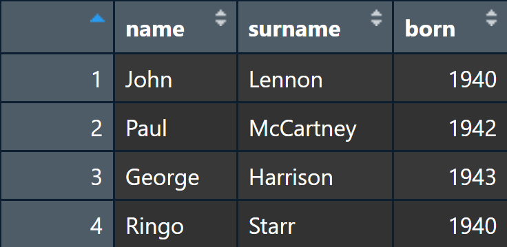

```r
View(beatles_data) # Ansehen des Dataframes im Viewer
```

## Datenstrukturen III: Dataframes

```r
mean(beatles_data$born)
```

```
[1] 1941.25
```

```r
nrow(beatles_data) # Anzahl Reihen
```

```
[1] 4
```

```r
length(beatles_data) # Anzahl Spalten
```

```
[1] 3
```

```r
dim(beatles_data) # Anzahl der Reihen und Anzahl der Spalten
```

```
[1] 4 3
```

## Datenstrukturen III: Dataframes

```r
names(beatles_data) # Namen der Spalten
```

```
[1] "name"    "surname" "born"
```

```r
str(beatles_data) # Struktur des Dataframes
```

```
'data.frame':   4 obs. of  3 variables:
 $ name   : chr  "John" "Paul" "George" "Ringo"
 $ surname: chr  "Lennon" "McCartney" "Harrison" "Starr"
 $ born   : num  1940 1942 1943 1940
```

## Das Tidyverse

```r
install.packages("tidyverse") # Installation eines Packages
library(tidyverse) # Laden eines Packages
```

- Sammlung an Packages dar, die nach denselben Prinzipien operieren und entsprechend kompatibel sind
- effiziente und konsistentere Alternative zur Verwendung gängiger R-Basis-Operationen dar, z.B. zur Datenmanipulation oder Visualisierung
- **eine** Art, R zu verwenden
- Häufig finden sich Mischungen des *tidy*-Syntax und des *base*-Syntax

## Das Tidyverse

Das *Tidyverse* beruht auf dem *tidy data*-Prinzip:

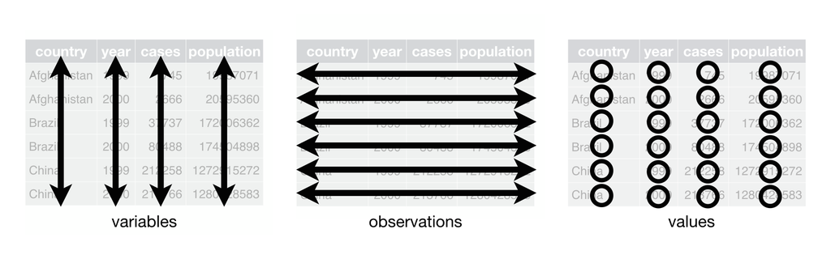

https://r4ds.hadley.nz/data-tidy.html#fig-tidy-structure

## Vergleich von *Base R* und *Tidyverse*

**Base R: Multiple Objekte** Hinweis: “Iris” ist ein Testdatensatz, welcher in R immer verfügbar ist

```r
data <- iris
subset <- data[data$Sepal.Length > 7, ]
mean_width <- mean(data$Sepal.Width)
sub_subset <- subset[subset$Sepal.Width > mean_width,]
result <- sum(sub_subset$Petal.Width)
result
```

```
[1] 8.5
```

## Vergleich von *Base R* und *Tidyverse*

**Alternative in Base R: verschachtelte Funktionen**

```r
result <- sum(data[data$Sepal.Length > 7 &
                     data$Sepal.Width > mean(data$Sepal.Width),
                   "Petal.Width"])
result
```

```
[1] 8.5
```

## Vergleich von *Base R* und *Tidyverse*

**Tidyverse: *Pipe***

```r
result <- data %>%
  filter(Sepal.Length > 7) %>%
  filter(Sepal.Width > mean(Sepal.Width)) %>%
  pull(Petal.Width) %>%
  sum()
result
```

```
[1] 8.5
```

## Anwendungsbeispiel Tidyverse: Data Wrangling I

Wir wollen die Höchstwerte der Blütenlänge für jede Spezies im *Iris*-Datensatz, wobei nur Exemplare mit überdurchschnittlicher Blütenbreite berücksichtigt werden sollen

```r
iris %>%
  group_by(Species) %>% # Gruppierung
  filter(Petal.Width > mean(Petal.Width)) %>% # Filterung
  slice_max(Petal.Length, n = 1) # Höchstwerte
```

```
# A tibble: 3 × 5
# Groups:   Species [3]
  Sepal.Length Sepal.Width Petal.Length Petal.Width Species
         <dbl>       <dbl>        <dbl>       <dbl> <fct>
1          5.1         3.8          1.9         0.4 setosa
2          6           2.7          5.1         1.6 versicolor
3          7.7         2.6          6.9         2.3 virginica
```

## Anwendungsbeispiel Tidyverse: Data Wrangling II

Durschnittliche Blütenbreite pro Spezies

```r
iris %>%
  group_by(Species) %>%
  summarise(mean_Petal.Width = mean(Petal.Width))
```

```
# A tibble: 3 × 2
  Species    mean_Petal.Width
  <fct>                 <dbl>
1 setosa                0.246
2 versicolor            1.33
3 virginica             2.03
```

## Visualisierung mit dem Tidyverse: *ggplot2*

ggplot verwendet **+** statt der Pipe ( %>% )

```r
ggplot(iris,
       # festlegen der Variablen mit aes()
       aes(x = Petal.Length, y = Petal.Width, color = Species)) +
  # festlegen des Plot Typs. Hier: Linie
  geom_line() +
  # Optional: Verwendung eines anderen Farbthemas
  theme_bw() +
  # Optional: manuelle Beschriftung
  labs(
    x = "Blütenblattlänge",
    y = "Blütenblattbreite",
    color = "Gattung",
    title = "Blütenlänge- und Breite nach Gattung"
  )
```

## Visualisierung mit dem Tidyverse: *ggplot2*

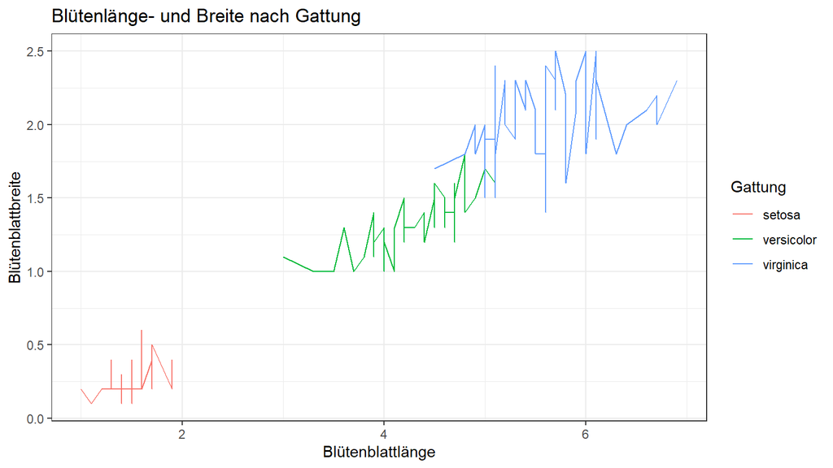

## Addendum: Was tun, wenn unser Code nicht funktioniert?

**Frag das Internet!**

- Fehlermeldung suchen auf Google, Duckduckgo…
- Nach dem Problem auf https://stackoverflow.com/ **suchen** oder nach der Lösung **fragen**
- Die Seite des Packages aufsuchen: idR. auf github.com - dort unter “Issues” suchen oder fragen, z.B. https://github.com/tidyverse/dplyr/issues

**Außerdem:**

`?function` oder `help(function)`, z.B. `?summarise`, öffnet die Hifeseite einer Funktion in RStudio